# Main_IA

2026-07-05

```r
library(readxl)
library(dplyr)
library(tidyr)
library(lubridate)
source("epic_ram.R")
source("Online_mul_ram.R")
library(readxl)
library(dplyr)
library(lubridate)
library(ggplot2)
library(plotly)
library(epic)
library(purrr)
```

# I. Data descritive

We first import the datasets. Each file rda contain: “ID belier”, “ID brebis”, moment of each chevauchement”

```r
rda_dir <- file.path("..", "Data", "rda_effet_male")

rda_files <- list.files(
  rda_dir,
  pattern = "\\.rda$",
  full.names = TRUE,
  ignore.case = TRUE
)

invisible(lapply(rda_files, load, envir = .GlobalEnv))

dataset = tools::file_path_sans_ext(basename(rda_files))

dataset
```

```
## [1] "Corse2024"     "Corse2025"     "LaCazotte2023" "LaCazotte2024" "LaFage2023"    "LaFage2025"
```

Summary data

```r
result <- bind_rows(
  lapply(dataset, function(dataset) {

    dat <- as.data.frame(
      get(dataset, envir = .GlobalEnv)
    )

    names(dat)[1:3] <- c("ID belier", "ID brebis","time")

    dates <- as.Date(dat$time)
    data.frame(
      dataset = dataset,
      nb_belier = n_distinct(dat$`ID belier`, na.rm = TRUE),
      nb_brebis = n_distinct(dat$`ID brebis`, na.rm = TRUE),
      date_start = min(dates),
      date_end = max(dates),
      nb_days = as.numeric(max(dates) - min(dates)) + 1
    )
  })
)

result
```

| dataset | nb_belier | nb_brebis | date_start | date_end | nb_days |
| --- | --- | --- | --- | --- | --- |
| Corse2024 | 1 | 31 | 2024-05-21 | 2024-05-24 | 4 |
| Corse2025 | 3 | 26 | 2025-05-20 | 2025-05-24 | 5 |
| LaCazotte2023 | 7 | 78 | 2023-05-09 | 2023-05-20 | 12 |
| LaCazotte2024 | 5 | 83 | 2024-05-21 | 2024-06-02 | 13 |
| LaFage2023 | 4 | 32 | 2023-07-04 | 2023-07-08 | 5 |
| LaFage2025 | 4 | 56 | 2025-06-13 | 2025-07-11 | 29 |

Bar chart showing the number of events for each ram ( exampmle here: LaCazotte2023 and Corse 2025 )

```r
LaCazotte2023_count <- LaCazotte2023 %>%
  filter(!is.na(time)) %>%
  count(`ID belier`, name = "n_events") %>%
  mutate(`ID belier` = as.factor(`ID belier`))

Corse2025_count <- Corse2025 %>%
  filter(!is.na(time)) %>%
  count(`ID belier`, name = "n_events") %>%
  mutate(`ID belier` = as.factor(`ID belier`))

ggplot(LaCazotte2023_count, aes(x = `ID belier`, y = n_events)) +
  geom_col() +
  labs(
    title = "Number of events for each ram -- La Cazotte 2023",
    x = "Ram ID",
    y = "Number of events"
  ) +
  theme_bw()
```

[figure not shown]

```r
ggplot(Corse2025_count, aes(x = `ID belier`, y = n_events)) +
  geom_col() +
  labs(
    title = "Number of events for each ram -- Corse 2025",
    x = "Ram ID",
    y = "Number of events"
  ) +
  theme_bw()
```

[figure not shown]

Comment: : Each raw material has a different level of activity; therefore, we predict that the effect of each raw differs.

# II. Application our algorithms to dataset

## 1. Genaral function

These functions below prepares the data for algorithms: standardizes column names, converts event timestamps to a unified time scale (hours or days), and sets markers for “before” and “after” (e.g., 1).

```r
parse_time <- function(x) {
  lubridate::force_tz(x, tzone = "UTC")}
```

```r
prepare_algorithm_data <- function(dat, time_unit = "hours") {

  dat <- as.data.frame(dat)
  names(dat)[1:3] <- c("ID_belier", "ID_brebis", "time")

  dat$time <- parse_time(dat$time)

  day_start <- floor_date(min(dat$time, na.rm = TRUE), unit = "day")
  day_end   <- ceiling_date(max(dat$time, na.rm = TRUE), unit = "day")

  if (time_unit == "hours") {
    t_final <- as.numeric(difftime(day_end, day_start, units = "hours"))
    scale_time <- 3600
  } else {
    t_final <- as.numeric(difftime(day_end, day_start, units = "days"))
    scale_time <- 3600 * 24
  }

  dat_epic <- dat %>%
    mutate(
      event_time = as.numeric(difftime(time, day_start, units = "secs")) / scale_time,
      TIMES = 1
    ) %>%
transmute(
  id_original = ID_brebis,
  id = as.integer(factor(ID_brebis)),
  id_char = as.character(ID_brebis),
  time = as.numeric(event_time),
  marks = as.numeric(TIMES),
  numAlpha = as.character(ID_belier),
  ram = as.character(ID_belier)
    ) %>%
    filter(
      !is.na(id_original),
      !is.na(id),
      !is.na(time),
      !is.na(marks),
      !is.na(numAlpha)
    ) %>%
    arrange(id, time)

  list(
    dat_epic = dat_epic,
    t_final = t_final,
    day_start = day_start,
    day_end = day_end
  )
}
```

Genaral function for offline running with marks fixing

```r
run_offline <- function(dat_epic, t_final,nprec = 10,alpha = 0.05, nb_MC = 200,seed = 123) {
  ram_levels <- sort(unique(dat_epic$numAlpha))
  init_by_ram <- dat_epic %>%
    group_by(numAlpha) %>%
    summarise(n_events = n(), .groups = "drop") %>%
    arrange(numAlpha)

  nb_indiv <- length(unique(dat_epic$id))
  lambda_bar_ram <- init_by_ram$n_events / (nb_indiv * t_final)

  lambda_init <- cbind(
    before = pmax(lambda_bar_ram * 0.5, 0.01),
    after  = pmax(lambda_bar_ram * 2, 0.01)
  )

  mu_init <- matrix( 1, nrow = length(ram_levels), ncol = 2)

  colnames(lambda_init) <- c("before", "after")
  colnames(mu_init) <- c("before", "after")
  rownames(lambda_init) <- ram_levels
  rownames(mu_init) <- ram_levels

  set.seed(seed)

  time_run <- system.time({
    out <- detectS_BH_m(
      datain = dat_epic %>% select(id, time, marks, numAlpha),
      lambda0 = lambda_init,
      mu0 = mu_init,
      nprec = nprec,
      alpha = alpha,
      nb_MC = nb_MC,
      t_final = t_final
    )
  })

  lambda_hat <- out$lambda_n
  mu_hat <- out$mu_n

  Si_table <- dat_epic %>%
    distinct(id, id_original) %>%
    arrange(id) %>%
    mutate(S_offline = out$outBH$S) %>%
    transmute(
      id = as.character(id_original),
      S_offline = S_offline
    )

  param_offline <- data.frame(
    ram = rownames(lambda_hat),
    lambda_before = lambda_hat[, "before"],
    lambda_after  = lambda_hat[, "after"],
    mu_before     = mu_hat[, "before"],
    mu_after      = mu_hat[, "after"]
  )

  list(
    out = out,
    time = time_run,
    lambda_hat = lambda_hat,
    mu_hat = mu_hat,
    Si_table = Si_table,
    param_offline = param_offline
  )
}
```

Genaral function fo Online running with marks fixing

```r
run_online <- function(dat_epic, t_final, lambda_hat, d_min, B = 200,  alpha = 0.05,
                       seed = 123,verbose = TRUE, return_null = TRUE) {

  dat_online <- dat_epic %>%
    transmute(
      id = id_char,
      time = as.numeric(time),
      marks = as.numeric(marks),
      ram = as.character(ram)
    ) %>%
    filter(
      !is.na(id),
      !is.na(time),
      !is.na(marks),
      !is.na(ram)
    ) %>%
    arrange(id, time)

  ids <- sort(unique(dat_online$id))

  lambda0_vec <- lambda_hat[, "before"]
  lambda1_vec <- lambda_hat[, "after"]

  mu0_vec <- rep(1, length(lambda0_vec))
  mu1_vec <- rep(1, length(lambda1_vec))

  names(lambda0_vec) <- rownames(lambda_hat)
  names(lambda1_vec) <- rownames(lambda_hat)
  names(mu0_vec) <- rownames(lambda_hat)
  names(mu1_vec) <- rownames(lambda_hat)

  set.seed(seed)

  time_run <- system.time({
    out <- detect_rupture_herd_online_FWER_ram(
      dat_herd = dat_online,
      ids = ids,
      K = ceiling(t_final),
      lambda0 = lambda0_vec,
      mu0 = mu0_vec,
      lambda1 = lambda1_vec,
      mu1 = mu1_vec,
      B = B,
      alpha = alpha,
      d_min = d_min,
      seed = seed,
      verbose = verbose,
      return_null = return_null,
      ram_levels = rownames(lambda_hat)
    )
  })

  list(
    out = out,
    time = time_run,
    dat_online = dat_online
  )
}
```

The code below create a table compare between offline and online algo, a graph plotting events, S_offline, S_online, and alarm time.

```r
compare_and_plot_algorithms <- function(dat_epic, t_final,
                                        off, on,
                                        dataset_name = "",
                                        time_unit = "hours",
                                        eps = 1e-8) {
  compare_tab <- off$Si_table %>%
    left_join(
      on$out$result %>%
        mutate(id = as.character(id)) %>%
        transmute(
          id,
          alarm,
          alarm_time = tau,
          S_online = S_hat,
          p_at_alarm,
          G_at_alarm
        ),
      by = "id"
    ) %>%
    mutate(
      alarm_time = ifelse(
        is.na(alarm_time) | is.infinite(alarm_time),
        t_final,
        alarm_time
      ),
      S_online = ifelse(
        is.na(S_online),
        t_final,
        S_online
      ),
      diff_S = S_online - S_offline,
      same_S = abs(diff_S) < eps
    )

  summary_tab <- compare_tab %>%
    summarise(
      dataset = dataset_name,
      unit = time_unit,
      same_S = sum(same_S, na.rm = TRUE),
      different_S = sum(!same_S, na.rm = TRUE),
      mean_alarm_delay = mean(
        alarm_time[alarm] - S_online[alarm],
        na.rm = TRUE
      )
    )

  id_order <- compare_tab %>%
    arrange(S_offline) %>%
    pull(id)

  events_plot <- dat_epic %>%
    transmute(
      id = factor(id_char, levels = id_order),
      time = as.numeric(time),
      marks = as.numeric(marks),
      type = "Event"
    )

  rupture_plot <- bind_rows(
    compare_tab %>%
      transmute(
        id = factor(id, levels = id_order),
        time = S_offline,
        type = ifelse(same_S, "Offline = Online", "Offline result")
      ),

    compare_tab %>%
      filter(!same_S) %>%
      transmute(
        id = factor(id, levels = id_order),
        time = S_online,
        type = "Online result"
      ),

    compare_tab %>%
      filter(alarm) %>%
      transmute(
        id = factor(id, levels = id_order),
        time = alarm_time,
        type = "Alarm"
      )
  )

  rupture_plot <- rupture_plot %>%
  mutate(
    type = factor(
      type,
      levels = c(
        "Alarm",
        "Offline = Online",
        "Offline result",
        "Online result"
      )
    )
  )
  title_text <- paste0(
    dataset_name,
    ": offline vs online detection with ram effect"
  )

  g <- ggplot() +
  geom_point(
    data = events_plot,
    aes(x = time, y = id, size = marks),
    color = "black",
    alpha = 0.6
  ) +
  geom_point(
    data = rupture_plot,
    aes(x = time, y = id, color = type),
    size = 2.2
  ) +
  scale_color_manual(
    values = c(
      "Alarm" = "#FFD700",
      "Offline = Online" = "blue",
      "Offline result" = "red",
      "Online result" = "green"
    )
  ) +
  labs(
    title = title_text,
    x = paste0("Time from start observation (", time_unit, ")"),
    y = "Ewe ID",
    color = "Type",
    size = "TIMES"
  ) +
  theme_bw() +
  theme(
    plot.title = element_text(size = 10, hjust = 0.5),
    axis.text.y = element_text(size = 6),
    axis.text.x = element_text(size = 7)
  )

  print(summary_tab)
  print(compare_tab)
  print(g)

  invisible(
    list(
      summary = summary_tab,
      compare = compare_tab,
      plot = g
    )
  )
}
```

## 2. Application to datasets

We now apply the functions below to our different datasets.

### Corse 24

```r
prep_corse24 <- prepare_algorithm_data(
  dat = Corse2024,
  time_unit = "hours"
)

off_corse24 <- run_offline(
  dat_epic = prep_corse24$dat_epic,
  t_final = prep_corse24$t_final,
  nprec = 50,
  alpha = 0.05,
  nb_MC = 500,
  seed = 123
)
```

```
## Estimated lambda:
##         before    after
## 93202 0.024154 0.367721
##
## Estimated mu:
##       before after
## 93202      1     1
##
## Estimated S:
##  [1] 96.00000 96.00000 96.00000 96.00000 41.81056 38.49833 96.00000 28.95222 96.00000 96.00000 96.00000 96.00000 42.46694 96.00000 96.00000 96.00000 96.00000 47.26889 42.13056 96.00000 96.00000 36.46111 65.37472 47.79611 39.59083 35.29972 96.00000 41.48917 67.90611 70.05500 96.00000
##
## P-values:
##  [1] 0.870 0.454 0.372 0.204 0.000 0.000 0.540 0.000 0.666 0.746 0.434 0.746 0.000 0.656 0.458 0.548 0.066 0.000 0.000 0.504 0.578 0.000 0.000 0.000 0.000 0.000 0.716 0.000 0.000 0.000 0.474
```

```r
on_corse24 <- run_online(
  dat_epic = prep_corse24$dat_epic,
  t_final = prep_corse24$t_final,
  lambda_hat = off_corse24$lambda_hat,
  d_min = 1,
  B = 200,
  alpha = 0.05,
  seed = 123
)
```

```
##          id alarm tau    S_hat p_at_alarm G_at_alarm
## 2    180085  TRUE  38 37.85917          0   5.397402
## 3    190077  TRUE  45 44.11056          0  10.585991
## 4    200970  TRUE  50 48.41333          0  10.346448
## 5    200983  TRUE  44 41.81056          0   7.416460
## 6    210257  TRUE  39 38.49833          0  24.333687
## 7    210260  TRUE  40 39.21583          0   7.899267
## 8    210262  TRUE  29 28.95222          0   8.152266
## 13   220203  TRUE  43 42.46694          0   7.985541
## 16   220229  TRUE  47 46.21028          0   5.174465
## 17   220231  TRUE  48 47.18111          0   5.164444
## 18   220234  TRUE  48 47.26889          0   5.194602
## 19   220235  TRUE  43 42.13056          0  16.038650
## 21   220242  TRUE  36 35.46306          0   7.984205
## 22   220244  TRUE  37 36.46111          0   5.260643
## 23   230102  TRUE  67 65.37472          0  18.501864
## 24   230110  TRUE  48 47.79611          0   5.375738
## 25   230111  TRUE  40 39.59083          0  27.088361
## 26 230122 ?  TRUE  38 35.29972          0   7.240954
## 28   230126  TRUE  43 41.48917          0  13.095396
## 29   230134  TRUE  70 67.90611          0   4.726396
## 30   230135  TRUE  71 70.05500          0   7.844010
## 31   230138  TRUE  21 20.68306          0   8.059789
```

```
##      dataset  unit same_S different_S mean_alarm_delay
## 1 Corse 2024 hours     23           0        0.9437879
##          id S_offline alarm alarm_time S_online p_at_alarm G_at_alarm    diff_S same_S
## 1    180063  96.00000 FALSE         96 96.00000         NA         NA   0.00000   TRUE
## 2    180085  96.00000  TRUE         38 37.85917          0   5.397402 -58.14083  FALSE
## 3    190077  96.00000  TRUE         45 44.11056          0  10.585991 -51.88944  FALSE
## 4    200970  96.00000  TRUE         50 48.41333          0  10.346448 -47.58667  FALSE
## 5    200983  41.81056  TRUE         44 41.81056          0   7.416460   0.00000   TRUE
## 6    210257  38.49833  TRUE         39 38.49833          0  24.333687   0.00000   TRUE
## 7    210260  96.00000  TRUE         40 39.21583          0   7.899267 -56.78417  FALSE
## 8    210262  28.95222  TRUE         29 28.95222          0   8.152266   0.00000   TRUE
## 9    210276  96.00000 FALSE         96 96.00000         NA         NA   0.00000   TRUE
## 10   210281  96.00000 FALSE         96 96.00000         NA         NA   0.00000   TRUE
## 11   210284  96.00000 FALSE         96 96.00000         NA         NA   0.00000   TRUE
## 12   220201  96.00000 FALSE         96 96.00000         NA         NA   0.00000   TRUE
```

[output cut: 19 more lines]

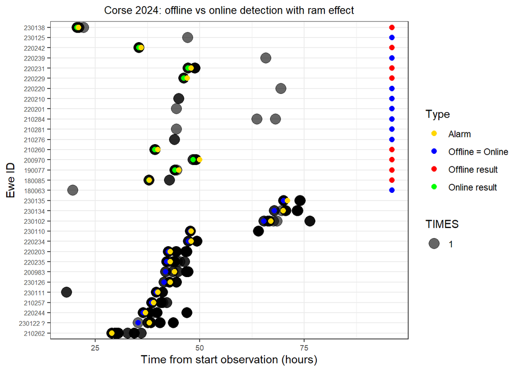

```r
res_corse24 <- compare_and_plot_algorithms(
  dat_epic = prep_corse24$dat_epic,
  t_final = prep_corse24$t_final,
  off = off_corse24,
  on = on_corse24,
  dataset_name = "Corse 2024",
  time_unit = "hours"
)
```

### Corse 25

```r
prep_corse25 <- prepare_algorithm_data(
  dat = Corse2025,
  time_unit = "hours"
)

off_corse25 <- run_offline(
  dat_epic = prep_corse25$dat_epic,
  t_final = prep_corse25$t_final,
  nprec = 50,
  alpha = 0.05,
  nb_MC = 500,
  seed = 123
)
```

```
## Estimated lambda:
##         before    after
## 91001 0.013521 0.173307
## 91807 0.010000 0.010000
## 93202 0.010000 0.010000
##
## Estimated mu:
##       before after
## 91001      1  1.00
## 91807      1  0.01
## 93202      1  1.00
##
## Estimated S:
##  [1]  39.70417  41.17528 120.00000  42.01611  45.70361 120.00000 120.00000 120.00000 120.00000 120.00000 120.00000  72.22694  40.90806  64.67722  34.87806 120.00000  29.92806 120.00000 120.00000 120.00000  45.64722 120.00000  36.28139  42.59278  49.11194 120.00000
##
## P-values:
##  [1] 0.000 0.000 0.828 0.000 0.000 0.794 0.886 0.706 0.098 0.584 0.198 0.000 0.000 0.000 0.000 0.392 0.000 0.816 0.078 0.938 0.000 0.846 0.000 0.000 0.000 0.898
```

```r
on_corse25 <- run_online(
  dat_epic = prep_corse25$dat_epic,
  t_final = prep_corse25$t_final,
  lambda_hat = off_corse25$lambda_hat,
  d_min = 1,
  B = 200,
  alpha = 0.05,
  seed = 123
)
```

```
##        id alarm tau    S_hat p_at_alarm G_at_alarm
## 1  190055  TRUE  40 39.70417          0  20.359432
## 2  190062  TRUE  42 41.17528          0  12.622409
## 4  210262  TRUE 102 42.01611          0   8.271274
## 5  210265  TRUE  46 45.70361          0  12.706830
## 9  220211  TRUE  67 50.43500          0   7.556495
## 12 220238  TRUE  73 72.22694          0  10.079827
## 13 220241  TRUE  45 40.90806          0  14.651191
## 14 230106  TRUE  66 64.67722          0   7.441152
## 15 230123  TRUE  35 34.87806          0   7.633028
## 17 230125  TRUE  32 29.92806          0  20.075634
## 19 230132  TRUE  69 67.82472          0   7.464720
## 21 240257  TRUE  55 45.64722          0   8.708907
## 23 240271  TRUE  38 36.28139          0   9.928741
## 24 240278  TRUE  53 42.59278          0  13.642097
## 25 240282  TRUE  62 49.11194          0  15.796532
```

```
##      dataset  unit same_S different_S mean_alarm_delay
## 1 Corse 2025 hours     24           0         8.125963
##        id S_offline alarm alarm_time  S_online p_at_alarm G_at_alarm    diff_S same_S
## 1  190055  39.70417  TRUE         40  39.70417          0  20.359432   0.00000   TRUE
## 2  190062  41.17528  TRUE         42  41.17528          0  12.622409   0.00000   TRUE
## 3  190063 120.00000 FALSE        120 120.00000         NA         NA   0.00000   TRUE
## 4  210262  42.01611  TRUE        102  42.01611          0   8.271274   0.00000   TRUE
## 5  210265  45.70361  TRUE         46  45.70361          0  12.706830   0.00000   TRUE
## 6  210282 120.00000 FALSE        120 120.00000         NA         NA   0.00000   TRUE
## 7  210283 120.00000 FALSE        120 120.00000         NA         NA   0.00000   TRUE
## 8  220206 120.00000 FALSE        120 120.00000         NA         NA   0.00000   TRUE
## 9  220211 120.00000  TRUE         67  50.43500          0   7.556495 -69.56500  FALSE
## 10 220221 120.00000 FALSE        120 120.00000         NA         NA   0.00000   TRUE
## 11 220223 120.00000 FALSE        120 120.00000         NA         NA   0.00000   TRUE
## 12 220238  72.22694  TRUE         73  72.22694          0  10.079827   0.00000   TRUE
## 13 220241  40.90806  TRUE         45  40.90806          0  14.651191   0.00000   TRUE
## 14 230106  64.67722  TRUE         66  64.67722          0   7.441152   0.00000   TRUE
## 15 230123  34.87806  TRUE         35  34.87806          0   7.633028   0.00000   TRUE
## 16 230124 120.00000 FALSE        120 120.00000         NA         NA   0.00000   TRUE
## 17 230125  29.92806  TRUE         32  29.92806          0  20.075634   0.00000   TRUE
## 18 230127 120.00000 FALSE        120 120.00000         NA         NA   0.00000   TRUE
## 19 230132 120.00000  TRUE         69  67.82472          0   7.464720 -52.17528  FALSE
## 20 230137 120.00000 FALSE        120 120.00000         NA         NA   0.00000   TRUE
## 21 240257  45.64722  TRUE         55  45.64722          0   8.708907   0.00000   TRUE
## 22 240265 120.00000 FALSE        120 120.00000         NA         NA   0.00000   TRUE
## 23 240271  36.28139  TRUE         38  36.28139          0   9.928741   0.00000   TRUE
## 24 240278  42.59278  TRUE         53  42.59278          0  13.642097   0.00000   TRUE
## 25 240282  49.11194  TRUE         62  49.11194          0  15.796532   0.00000   TRUE
## 26 240288 120.00000 FALSE        120 120.00000         NA         NA   0.00000   TRUE
```

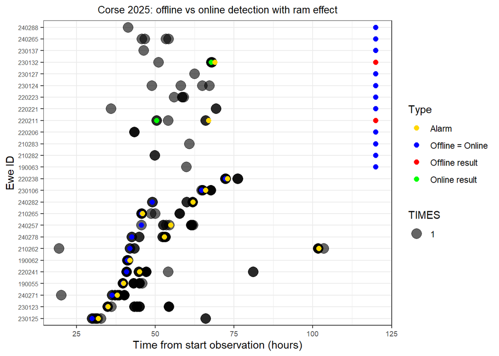

```r
res_corse25 <- compare_and_plot_algorithms(
  dat_epic = prep_corse25$dat_epic,
  t_final = prep_corse25$t_final,
  off = off_corse25,
  on = on_corse25,
  dataset_name = "Corse 2025",
  time_unit = "hours"
)
```

### La Fage 2023

```r
prep_LaFage2023 <- prepare_algorithm_data(
  dat =LaFage2023,
  time_unit = "hours"
)

off_LaFage2023 <- run_offline(
  dat_epic = prep_LaFage2023$dat_epic,
  t_final = prep_LaFage2023$t_final,
  nprec = 50,
  alpha = 0.05,
  nb_MC = 500,
  seed = 123
)
```

```
## Estimated lambda:
##          before    after
## 213665 0.012356 0.051016
## 213668 0.010000 0.010000
## 213711 0.011380 0.214527
## 213777 0.011380 0.078486
##
## Estimated mu:
##        before after
## 213665      1     1
## 213668      1     1
## 213711      1     1
## 213777      1     1
##
## Estimated S:
##  [1] 120.00000 120.00000 120.00000 120.00000  87.48194 120.00000  30.79778 120.00000  40.86722  64.36944  33.75139 120.00000  31.27222  52.84083 120.00000  60.78528 120.00000 120.00000 120.00000  39.28972 120.00000  40.56806 120.00000 120.00000  73.50417 120.00000 120.00000 120.00000 120.00000 12…
##
## P-values:
##  [1] 0.688 0.774 0.798 0.084 0.000 0.606 0.000 0.124 0.000 0.000 0.000 0.040 0.000 0.000 0.832 0.000 0.078 0.868 0.880 0.000 0.922 0.000 0.862 0.766 0.000 0.862 0.546 0.818 0.874 0.988 0.756 0.070
```

```r
on_LaFage2023 <- run_online(
  dat_epic = prep_LaFage2023$dat_epic,
  t_final = prep_LaFage2023$t_final,
  lambda_hat = off_LaFage2023$lambda_hat,
  d_min = 1,
  B = 200,
  alpha = 0.05,
  seed = 123
)
```

```
##        id alarm tau    S_hat p_at_alarm G_at_alarm
## 1  182103  TRUE  59 58.37917          0   8.316349
## 4  192193  TRUE  64 58.80750          0   7.205667
## 5  192249  TRUE  88 87.48194          0  21.110297
## 6  202045  TRUE  62 57.64278          0   7.463695
## 7  202053  TRUE  31 30.79778          0  21.179005
## 8  202116  TRUE  43 42.93056          0  20.534502
## 9  202196  TRUE  41 40.86722          0  14.641808
## 10 202242  TRUE  65 64.36944          0  11.551473
## 11 202290  TRUE  34 33.75139          0   7.647373
## 12 202451  TRUE  50 42.99639          0   9.582757
## 13 213074  TRUE  32 31.27222          0  49.696784
## 14 213097  TRUE  53 52.84083          0  29.316481
## 16 213129  TRUE  62 60.78528          0  11.371017
## 17 213254  TRUE  66 64.71028          0   7.325761
## 18 213261  TRUE  49 42.50472          0   7.648743
## 20 213348  TRUE  40 38.77667          0  26.051182
## 22 213442  TRUE  49 40.56806          0  32.634047
## 25 223161  TRUE  76 73.50417          0  20.499337
## 27 223223  TRUE  78 71.90000          0   7.770850
```

```
##        dataset  unit same_S different_S mean_alarm_delay
## 1 La Fage 2023 hours     23           0         2.479664
##        id S_offline alarm alarm_time  S_online p_at_alarm G_at_alarm      diff_S same_S
## 1  182103 120.00000  TRUE         59  58.37917          0   8.316349 -61.6208333  FALSE
## 2  192010 120.00000 FALSE        120 120.00000         NA         NA   0.0000000   TRUE
## 3  192072 120.00000 FALSE        120 120.00000         NA         NA   0.0000000   TRUE
## 4  192193 120.00000  TRUE         64  58.80750          0   7.205667 -61.1925000  FALSE
## 5  192249  87.48194  TRUE         88  87.48194          0  21.110297   0.0000000   TRUE
## 6  202045 120.00000  TRUE         62  57.64278          0   7.463695 -62.3572222  FALSE
## 7  202053  30.79778  TRUE         31  30.79778          0  21.179005   0.0000000   TRUE
## 8  202116 120.00000  TRUE         43  42.93056          0  20.534502 -77.0694444  FALSE
## 9  202196  40.86722  TRUE         41  40.86722          0  14.641808   0.0000000   TRUE
## 10 202242  64.36944  TRUE         65  64.36944          0  11.551473   0.0000000   TRUE
## 11 202290  33.75139  TRUE         34  33.75139          0   7.647373   0.0000000   TRUE
## 12 202451 120.00000  TRUE         50  42.99639          0   9.582757 -77.0036111  FALSE
```

[output cut: 20 more lines]

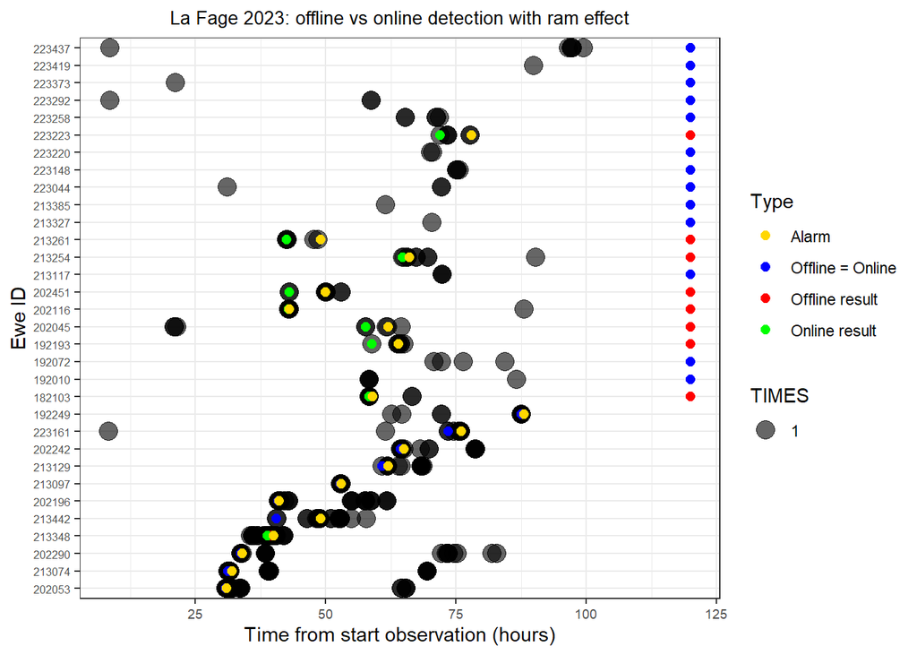

```r
res_LaFage2023 <- compare_and_plot_algorithms(
  dat_epic = prep_LaFage2023$dat_epic,
  t_final = prep_LaFage2023$t_final,
  off = off_LaFage2023,
  on = on_LaFage2023,
  dataset_name = "La Fage 2023",
  time_unit = "hours"
)
```

### La Fage 2025

```r
prep_LaFage2025 <- prepare_algorithm_data(
  dat =LaFage2025,
  time_unit = "days"
)

off_LaFage2025 <- run_offline(
  dat_epic = prep_LaFage2025$dat_epic,
  t_final = prep_LaFage2025$t_final,
  nprec = 50,
  alpha = 0.05,
  nb_MC = 500,
  seed = 123
)
```

```
## Estimated lambda:
##         before    after
## 13777 0.083375 0.617039
## 13779 0.051780 1.064856
## 33757 0.055291 3.173933
## 33846 0.120236 1.399172
##
## Estimated mu:
##       before after
## 13777      1     1
## 13779      1     1
## 33757      1     1
## 33846      1     1
##
## Estimated S:
##  [1] 29.000000 17.629745 21.108553  6.919641 10.308183 29.000000 13.684954  7.850833 21.874375 15.630752 10.557326  8.605035 29.000000 13.948032  0.456157 24.496319 14.788380 29.000000 23.269884 17.570231  8.245046 24.832315 29.000000 29.000000  0.311644 22.823900 29.000000  8.786991 29.000000 22…
##
## P-values:
##  [1] 1.000 0.000 0.000 0.000 0.000 0.834 0.000 0.000 0.000 0.000 0.000 0.000 0.748 0.000 0.000 0.000 0.000 1.000 0.000 0.000 0.000 0.000 0.590 0.056 0.000 0.000 0.544 0.000 0.684 0.000 0.000 0.000 0.000 0.000 1.000 0.494 0.974 0.000 0.000 0.000 0.924 0.000 0.778 0.000 0.838 0.000 0.436 0.000 1.00…
```

```r
on_LaFage2025 <- run_online(
  dat_epic = prep_LaFage2025$dat_epic,
  t_final = prep_LaFage2025$t_final,
  lambda_hat = off_LaFage2025$lambda_hat,
  d_min = 1,
  B = 200,
  alpha = 0.05,
  seed = 123
)
```

```
##        id alarm tau     S_hat p_at_alarm G_at_alarm
## 2  202212  TRUE  18 17.629745          0  64.086048
## 3  202221  TRUE  22 21.108553          0 528.940889
## 4  202290  TRUE   7  6.919641          0  19.155769
## 5  202503  TRUE  11 10.308183          0 238.894699
## 6  202527  TRUE  18 17.103507          0  14.304408
## 7  213057  TRUE  14 13.684954          0  69.298512
## 8  213129  TRUE   8  7.850833          0 124.666964
## 9  213174  TRUE  10  9.325521          0   8.141036
## 10 213210  TRUE  16 15.630752          0  71.430503
## 11 213339  TRUE  11 10.557326          0  41.543864
## 12 213355  TRUE   9  8.605035          0 227.444577
## 13 213379  TRUE  17 16.587697          0  13.982433
## 14 213445  TRUE  14 13.948032          0 181.946398
## 15 223050  TRUE   1  0.000000          0  87.786783
```

[output cut: 32 more lines]

```
##        dataset unit same_S different_S mean_alarm_delay
## 1 La Fage 2025 days     40           0        0.5267006
##        id  S_offline alarm alarm_time  S_online p_at_alarm G_at_alarm      diff_S same_S
## 1  202073 29.0000000 FALSE         29 29.000000         NA         NA   0.0000000   TRUE
## 2  202212 17.6297454  TRUE         18 17.629745          0  64.086048   0.0000000   TRUE
## 3  202221 21.1085532  TRUE         22 21.108553          0 528.940889   0.0000000   TRUE
## 4  202290  6.9196412  TRUE          7  6.919641          0  19.155769   0.0000000   TRUE
## 5  202503 10.3081829  TRUE         11 10.308183          0 238.894699   0.0000000   TRUE
## 6  202527 29.0000000  TRUE         18 17.103507          0  14.304408 -11.8964931  FALSE
## 7  213057 13.6849537  TRUE         14 13.684954          0  69.298512   0.0000000   TRUE
## 8  213129  7.8508333  TRUE          8  7.850833          0 124.666964   0.0000000   TRUE
## 9  213174 21.8743750  TRUE         10  9.325521          0   8.141036 -12.5488542  FALSE
## 10 213210 15.6307523  TRUE         16 15.630752          0  71.430503   0.0000000   TRUE
## 11 213339 10.5573264  TRUE         11 10.557326          0  41.543864   0.0000000   TRUE
## 12 213355  8.6050347  TRUE          9  8.605035          0 227.444577   0.0000000   TRUE
```

[output cut: 44 more lines]

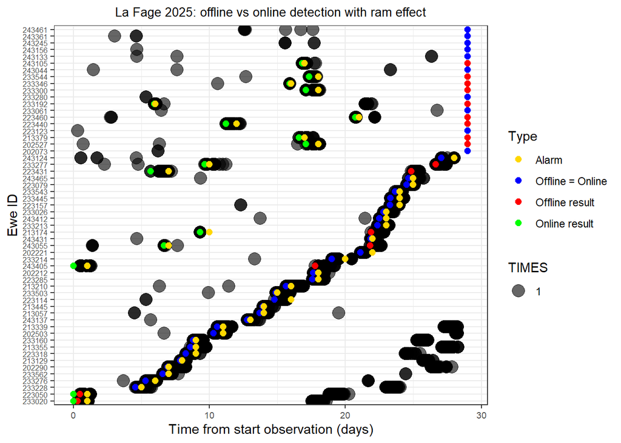

```r
res_LaFage2025 <- compare_and_plot_algorithms(
  dat_epic = prep_LaFage2025$dat_epic,
  t_final = prep_LaFage2025$t_final,
  off = off_LaFage2025,
  on = on_LaFage2025,
  dataset_name = "La Fage 2025",
  time_unit = "days"
)
```

### La Cazotte 2023

```r
prep_LaCazotte2023 <- prepare_algorithm_data(
  dat =LaCazotte2023,
  time_unit = "days"
)

off_LaCazotte2023 <- run_offline(
  dat_epic = prep_LaCazotte2023$dat_epic,
  t_final = prep_LaCazotte2023$t_final,
  nprec = 50,
  alpha = 0.05,
  nb_MC = 500,
  seed = 123
)
```

```
## Estimated lambda:
##         before    after
## 02322 0.037835 1.021020
## 02568 0.025223 1.107210
## 02644 0.010000 0.010000
## 11171 0.022070 0.086190
## 11490 0.275877 1.213290
## 21265 0.011035 0.023205
## 91601 0.040987 0.709410
##
## Estimated mu:
##       before after
## 02322      1  1.00
## 02568      1  1.00
## 02644      1  0.01
## 11171      1  1.00
## 11490      1  1.00
## 21265      1  1.00
## 91601      1  1.00
##
## Estimated S:
##  [1] 12.000000  0.660683 12.000000  1.404549  1.074931 12.000000  1.007755 12.000000 12.000000  2.810220  1.771725  2.834433 12.000000  2.718796 12.000000 12.000000  2.321111 12.000000  1.086435 12.000000 12.000000 12.000000  2.845278  2.695613 12.000000 12.000000  3.085880  2.778646 12.000000 12…
##
## P-values:
##  [1] 0.356 0.000 0.224 0.000 0.000 0.974 0.000 0.976 0.980 0.000 0.000 0.000 0.990 0.000 0.286 0.300 0.000 0.658 0.000 0.966 0.990 0.982 0.000 0.000 0.976 0.990 0.000 0.000 0.964 0.976 0.966 0.978 0.976 0.244 0.976 0.568 0.906 0.000 0.572 0.000 0.976 0.000 0.978 0.000 0.342 0.964 0.880 0.916 0.91…
```

```r
on_LaCazotte2023 <- run_online(
  dat_epic = prep_LaCazotte2023$dat_epic,
  t_final = prep_LaCazotte2023$t_final,
  lambda_hat = off_LaCazotte2023$lambda_hat,
  d_min = 1,
  B = 200,
  alpha = 0.05,
  seed = 123
)
```

```
##       id alarm tau     S_hat p_at_alarm G_at_alarm
## 2  02159  TRUE   1 0.0000000          0  33.317888
## 4  02169  TRUE   2 1.4045486          0  42.053860
## 5  02192  TRUE   2 1.0749306          0  39.461844
## 7  02243  TRUE   2 1.0077546          0 396.639953
## 10 02479  TRUE   3 2.8102199          0  90.374840
## 11 02490  TRUE   2 1.7717245          0  33.358601
## 12 02531  TRUE   3 2.8344329          0  21.780787
## 14 11131  TRUE   3 2.7187963          0 120.959784
## 17 11172  TRUE   3 1.3959259          0  54.896425
## 19 11214  TRUE   2 1.0864352          0 153.014330
## 23 11627  TRUE   3 2.8452778          0  29.363491
## 24 11697  TRUE   3 2.6956134          0  54.733665
## 27 11786  TRUE   4 3.0858796          0  67.200772
## 28 21110  TRUE   3 2.7786458          0  43.434097
```

[output cut: 27 more lines]

```
##           dataset unit same_S different_S mean_alarm_delay
## 1 La Cazotte 2023 days     64           0        0.6253644
##       id  S_offline alarm alarm_time   S_online p_at_alarm G_at_alarm      diff_S same_S
## 1  02128 12.0000000 FALSE         12 12.0000000         NA         NA   0.0000000   TRUE
## 2  02159  0.6606829  TRUE          1  0.0000000          0  33.317888  -0.6606829  FALSE
## 3  02162 12.0000000 FALSE         12 12.0000000         NA         NA   0.0000000   TRUE
## 4  02169  1.4045486  TRUE          2  1.4045486          0  42.053860   0.0000000   TRUE
## 5  02192  1.0749306  TRUE          2  1.0749306          0  39.461844   0.0000000   TRUE
## 6  02221 12.0000000 FALSE         12 12.0000000         NA         NA   0.0000000   TRUE
## 7  02243  1.0077546  TRUE          2  1.0077546          0 396.639953   0.0000000   TRUE
## 8  02253 12.0000000 FALSE         12 12.0000000         NA         NA   0.0000000   TRUE
## 9  02378 12.0000000 FALSE         12 12.0000000         NA         NA   0.0000000   TRUE
## 10 02479  2.8102199  TRUE          3  2.8102199          0  90.374840   0.0000000   TRUE
## 11 02490  1.7717245  TRUE          2  1.7717245          0  33.358601   0.0000000   TRUE
## 12 02531  2.8344329  TRUE          3  2.8344329          0  21.780787   0.0000000   TRUE
```

[output cut: 66 more lines]

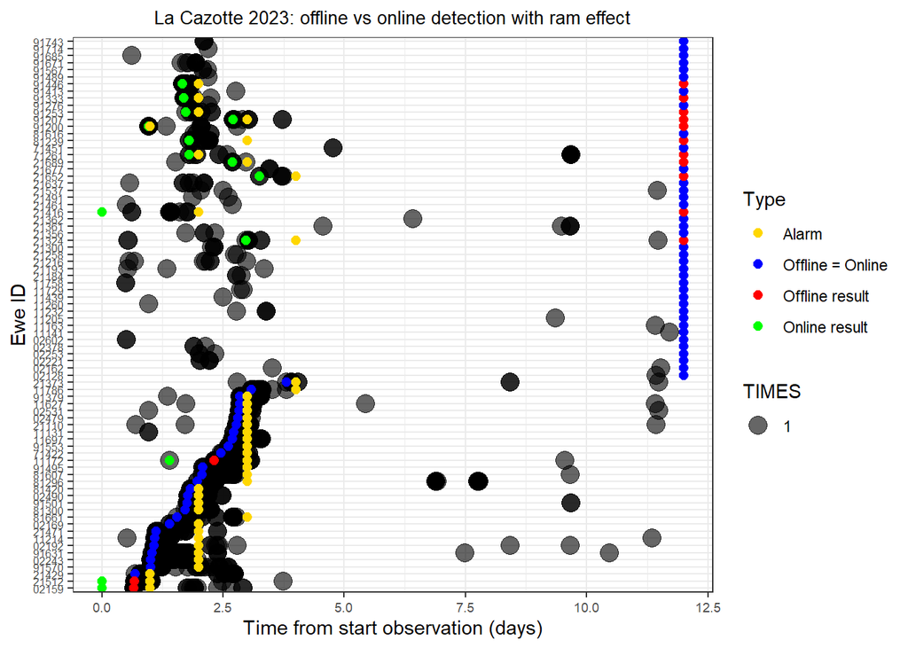

```r
res_LaCazotte2023 <- compare_and_plot_algorithms(
  dat_epic = prep_LaCazotte2023$dat_epic,
  t_final = prep_LaCazotte2023$t_final,
  off = off_LaCazotte2023,
  on = on_LaCazotte2023,
  dataset_name = "La Cazotte 2023",
  time_unit = "days"
)
```

### La Cazotte 2024

```r
prep_LaCazotte2024 <- prepare_algorithm_data(
  dat =LaCazotte2024,
  time_unit = "days"
)

off_LaCazotte2024 <- run_offline(
  dat_epic = prep_LaCazotte2024$dat_epic,
  t_final = prep_LaCazotte2024$t_final,
  nprec = 50,
  alpha = 0.05,
  nb_MC = 500,
  seed = 123
)
```

```
## Estimated lambda:
##         before    after
## 11171 0.058348 0.972751
## 11197 0.027522 0.480516
## 21261 0.123300 0.251978
## 2568  0.056146 0.615295
## 2644  0.028623 0.070319
##
## Estimated mu:
##       before after
## 11171      1     1
## 11197      1     1
## 21261      1     1
## 2568       1     1
## 2644       1     1
##
## Estimated S:
##  [1] 13.000000 13.000000 13.000000 13.000000 13.000000  1.896817 13.000000  0.474213 13.000000 13.000000 13.000000 13.000000 13.000000 13.000000 13.000000 13.000000 13.000000 13.000000  2.198669 13.000000 13.000000 13.000000  1.756215 13.000000  3.150231 13.000000 13.000000 13.000000 13.000000 13…
##
## P-values:
##  [1] 0.842 0.942 0.672 0.716 0.918 0.000 0.924 0.000 0.930 0.828 0.940 0.918 0.954 0.902 0.930 0.900 0.804 0.946 0.000 0.898 0.930 0.924 0.000 0.252 0.000 0.920 0.832 0.776 0.616 0.954 0.884 0.786 0.952 0.924 0.934 0.368 0.000 0.000 0.946 0.876 0.942 0.000 0.918 0.850 0.884 0.920 0.082 0.700 0.95…
```

```r
on_LaCazotte2024 <- run_online(
  dat_epic = prep_LaCazotte2024$dat_epic,
  t_final = prep_LaCazotte2024$t_final,
  lambda_hat = off_LaCazotte2024$lambda_hat,
  d_min = 1,
  B = 200,
  alpha = 0.05,
  seed = 123
)
```

```
##       id alarm tau     S_hat   p_at_alarm G_at_alarm
## 3  02154  TRUE   3 1.8997685 0.000000e+00  13.855454
## 4  02159  TRUE   3 2.6732523 0.000000e+00  12.713831
## 6  02206  TRUE   3 1.8968171 0.000000e+00  33.041226
## 8  02242  TRUE   1 0.0000000 0.000000e+00  35.376663
## 17 11163  TRUE   3 2.4538426 6.024096e-05   7.295886
## 19 11232  TRUE   3 2.1986690 0.000000e+00  37.711630
## 23 11376  TRUE   2 1.7562153 0.000000e+00  19.184782
## 24 11420  TRUE   3 1.8995602 0.000000e+00  20.006859
## 25 11577  TRUE   4 3.1502315 0.000000e+00  26.816691
## 28 11697  TRUE   3 2.6985880 0.000000e+00   8.944563
## 32 21150  TRUE   1 0.0000000 0.000000e+00  11.302075
## 36 21536  TRUE   2 1.6269213 0.000000e+00  16.099951
## 37 31114  TRUE   3 2.1764352 0.000000e+00  77.241555
## 38 31173  TRUE   5 4.2937616 0.000000e+00  72.737727
```

[output cut: 16 more lines]

```
##           dataset unit same_S different_S mean_alarm_delay
## 1 La Cazotte 2024 days     68           0        0.7484309
##       id  S_offline alarm alarm_time   S_online   p_at_alarm G_at_alarm     diff_S same_S
## 1  02125 13.0000000 FALSE         13 13.0000000           NA         NA   0.000000   TRUE
## 2  02128 13.0000000 FALSE         13 13.0000000           NA         NA   0.000000   TRUE
## 3  02154 13.0000000  TRUE          3  1.8997685 0.000000e+00  13.855454 -11.100231  FALSE
## 4  02159 13.0000000  TRUE          3  2.6732523 0.000000e+00  12.713831 -10.326748  FALSE
## 5  02169 13.0000000 FALSE         13 13.0000000           NA         NA   0.000000   TRUE
## 6  02206  1.8968171  TRUE          3  1.8968171 0.000000e+00  33.041226   0.000000   TRUE
## 7  02221 13.0000000 FALSE         13 13.0000000           NA         NA   0.000000   TRUE
## 8  02242  0.4742130  TRUE          1  0.0000000 0.000000e+00  35.376663  -0.474213  FALSE
## 9  02413 13.0000000 FALSE         13 13.0000000           NA         NA   0.000000   TRUE
## 10 02484 13.0000000 FALSE         13 13.0000000           NA         NA   0.000000   TRUE
## 11 02485 13.0000000 FALSE         13 13.0000000           NA         NA   0.000000   TRUE
## 12 02490 13.0000000 FALSE         13 13.0000000           NA         NA   0.000000   TRUE
```

[output cut: 71 more lines]

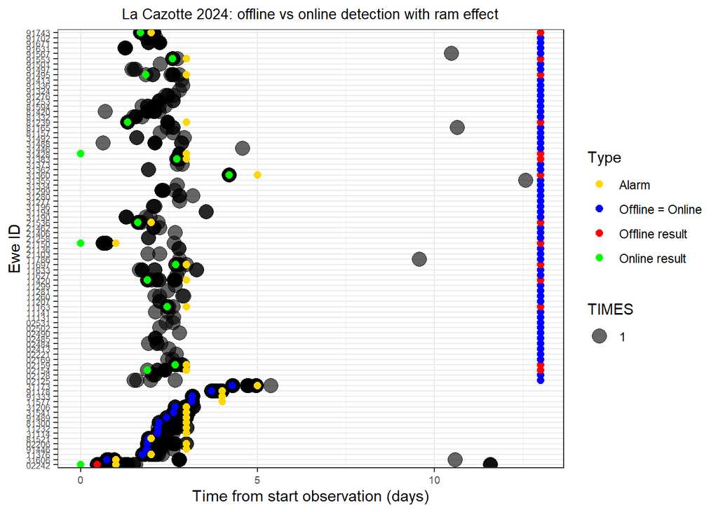

```r
res_LaCazotte2024 <- compare_and_plot_algorithms(
  dat_epic = prep_LaCazotte2024$dat_epic,
  t_final = prep_LaCazotte2024$t_final,
  off = off_LaCazotte2024,
  on = on_LaCazotte2024,
  dataset_name = "La Cazotte 2024",
  time_unit = "days"
)
```

###Epic

```r
data(ewe2014)

epic2014 <- ewe2014 %>%
  ungroup() %>%
  transmute(
    ID_belier = as.character(numAlpha),
    ID_brebis = as.character(RFID),
    time = Day
  ) %>%
  as.data.frame()

prep_epic2014 <- prepare_algorithm_data(
  dat =epic2014,
  time_unit = "days"
)

off_epic2014 <- run_offline(
  dat_epic = prep_epic2014$dat_epic,
  t_final = prep_epic2014$t_final,
  nprec = 50,
  alpha = 0.05,
  nb_MC = 500,
  seed = 123
)
```

```
## Estimated lambda:
##              before    after
## Alpha 0011 0.010000 0.824467
## Alpha 0014 0.010000 0.560786
## Alpha 0015 0.010000 0.844274
## Alpha 0016 0.015534 0.485272
## Alpha 0017 0.010000 0.418423
## Alpha 0018 0.010000 1.001492
## Alpha 0021 0.010000 0.461751
##
## Estimated mu:
##            before after
## Alpha 0011      1     1
## Alpha 0014      1     1
## Alpha 0015      1     1
## Alpha 0016      1     1
## Alpha 0017      1     1
## Alpha 0018      1     1
## Alpha 0021      1     1
##
## Estimated S:
##   [1] 25.084676  2.835289 28.000000 28.000000 24.253264 24.272755 21.897743 24.250278 27.038009 15.786597 24.938854 18.849873 19.977581 14.808391 17.867731 27.048704 24.824421  2.842731 23.807870 22.835255 14.846944 24.843414 28.000000 17.926447 23.802060 24.952870 24.877859 28.000000 28.000000 2…
## [100] 22.819479 21.931053 23.862870 25.808912 21.192315 28.000000 28.000000 24.178449 24.822824 26.805336 26.940231 25.874317 19.870428 28.000000 22.819630 24.824734 28.000000 25.967894 24.835440 28.000000 25.806412 25.804641 26.814826 24.233102 23.935243 25.861111 28.000000 25.237847 23.854826 2…
##
## P-values:
##   [1] 0.000 0.000 0.124 0.056 0.000 0.000 0.000 0.000 0.000 0.000 0.000 0.000 0.000 0.000 0.000 0.000 0.000 0.000 0.000 0.000 0.000 0.000 0.694 0.000 0.000 0.000 0.000 0.396 0.494 0.000 0.156 0.000 0.000 0.014 0.000 0.000 0.000 0.000 0.000 0.000 0.792 0.156 0.000 0.000 0.000 0.000 0.000 0.000 0.0…
```

```r
on_epic2014 <- run_online(
  dat_epic = prep_epic2014$dat_epic,
  t_final = prep_epic2014$t_final,
  lambda_hat = off_epic2014$lambda_hat,
  d_min = 1,
  B = 200,
  alpha = 0.05,
  seed = 123
)
```

```
##              id alarm tau      S_hat p_at_alarm G_at_alarm
## 1    1002783064  TRUE  26 25.0846759          0  22.629097
## 2    1002783069  TRUE   3  2.8352894          0  49.928628
## 3    1002783082  TRUE  25 24.9190162          0   7.101694
## 5    1002783089  TRUE  25 24.2532639          0  33.459692
## 6    1002783094  TRUE  25 24.2727546          0  76.550845
## 7    1002783143  TRUE  22 21.8977431          0  22.058702
## 8    1002783161  TRUE  25 24.2502778          0 174.994290
## 9    1002783163  TRUE  28 27.0380093          0  10.294297
## 10   1002783164  TRUE  16 15.7865972          0  69.576615
## 11   1002783167  TRUE  25 24.9388542          0  26.338916
## 12   1002783168  TRUE  19 18.8498727          0  69.986937
## 13   1002783185  TRUE  20 19.9775810          0  84.212342
## 14   1002783206  TRUE  15 14.8083912          0 175.207384
## 15   1002783207  TRUE  18 17.8677315          0  37.260355
```

[output cut: 126 more lines]

```
##    dataset unit same_S different_S mean_alarm_delay
## 1 epic2014 days    133           0        0.4230381
##              id S_offline alarm alarm_time   S_online p_at_alarm G_at_alarm     diff_S same_S
## 1    1002783064 25.084676  TRUE         26 25.0846759          0  22.629097   0.000000   TRUE
## 2    1002783069  2.835289  TRUE          3  2.8352894          0  49.928628   0.000000   TRUE
## 3    1002783082 28.000000  TRUE         25 24.9190162          0   7.101694  -3.080984  FALSE
## 4    1002783087 28.000000 FALSE         28 28.0000000         NA         NA   0.000000   TRUE
## 5    1002783089 24.253264  TRUE         25 24.2532639          0  33.459692   0.000000   TRUE
## 6    1002783094 24.272755  TRUE         25 24.2727546          0  76.550845   0.000000   TRUE
## 7    1002783143 21.897743  TRUE         22 21.8977431          0  22.058702   0.000000   TRUE
## 8    1002783161 24.250278  TRUE         25 24.2502778          0 174.994290   0.000000   TRUE
## 9    1002783163 27.038009  TRUE         28 27.0380093          0  10.294297   0.000000   TRUE
## 10   1002783164 15.786597  TRUE         16 15.7865972          0  69.576615   0.000000   TRUE
## 11   1002783167 24.938854  TRUE         25 24.9388542          0  26.338916   0.000000   TRUE
## 12   1002783168 18.849873  TRUE         19 18.8498727          0  69.986937   0.000000   TRUE
```

[output cut: 141 more lines]

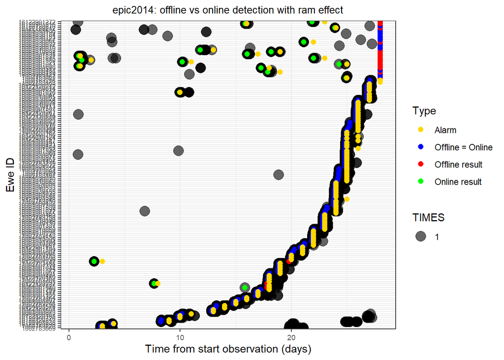

```r
res_epic2014 <- compare_and_plot_algorithms(
  dat_epic = prep_epic2014$dat_epic,
  t_final = prep_epic2014$t_final,
  off = off_epic2014,
  on = on_epic2014,
  dataset_name = "epic2014",
  time_unit = "days"
)
```

# III. Comparasion avec résultat d’IA

In this section, we use the previously obtained S_offline data and the AIbdatasets to discuss and analyze the relationship between the changed-point and the information derived from the AI.

In particular, we perform three analyses:

1. We plot the timeline of the estimated change point $S$ offiline, the manual heat date, and the AI date for each ewe.
2. We compute the AI success rate when the AI date occurs within 0–35 hours after the estimated change point $S$.
3. We compare the time difference between the estimated change point $S$ and the manual heat date.

## 1. General function

We first import the IA data. Each file rda contain: “ID_brebis”, “Jour IA”, “result IA”,“date predect chaleur manuelle”)

```r
rda_dir_IA <- file.path("..", "Data", "rda_IA")
rda_files_IA <- list.files(
  rda_dir_IA,
  pattern = "\\.rda$",
  full.names = TRUE,
  ignore.case = TRUE
)

invisible(lapply(rda_files_IA, load, envir = .GlobalEnv))

datasets_info_IA <- data.frame(
  dataset = tools::file_path_sans_ext(basename(rda_files_IA))
)
```

A common function to link the IA dataset and the prediction S_offline based on “ID brebis”.

```r
make_offline_IA_table <- function(compare_tab, prep, IA_table,
                                  time_unit = "hours") {

  scale_time <- ifelse(time_unit == "hours", 3600, 3600 * 24)

  IA_table <- as.data.frame(IA_table)

  names(IA_table)[1:4] <- c("ID_brebis", "Jour IA", "result IA", "date chaleur manuelle")

  IA_table <- IA_table %>%
    mutate(
      ID_brebis = trimws(as.character(ID_brebis)),
      `Jour IA` = parse_time(`Jour IA`),
      `date chaleur manuelle` = parse_time(`date chaleur manuelle`),
      `result IA` = ifelse(is.na(`result IA`), 0, `result IA`)
    ) %>%
    distinct(ID_brebis, .keep_all = TRUE)

  compare_tab %>%
    transmute(
      ID_brebis = trimws(as.character(id)),
      S_offline = S_offline,
      S_offline_datetime = parse_time(prep$day_start) + S_offline * scale_time
    ) %>%
    left_join(IA_table, by = "ID_brebis") %>%
    mutate(
      `result IA` = ifelse(is.na(`result IA`), 0, `result IA`)
    ) %>%
    select(
      ID_brebis,
      S_offline,
      S_offline_datetime,
      `Jour IA`,
      `result IA`,
      `date chaleur manuelle`
    )
}
```

The function below compares the offline estimated change point $S$ with the manual heat date.

It returns a summary table with: the total number of ewes, the number detected by the offline method, the number detected manually, the number not detected by either method, and the mean and variance of the absolute time difference between $S$ and manual heat among ewes detected by both methods.

```r
compare_offline_with_manual_heat <- function(data) {

  data <- data %>%
    mutate(
      S_offline_datetime = parse_time(S_offline_datetime),
      `date chaleur manuelle` = parse_time(`date chaleur manuelle`)
    )

  T_offline <- max(data$S_offline, na.rm = TRUE)
  T_datetime <- data$S_offline_datetime[which.max(data$S_offline)]

  data %>%
    mutate(
      S_detected = S_offline < T_offline,
      manual_detected = !is.na(`date chaleur manuelle`),

      manual_date = `date chaleur manuelle`,
      manual_date = replace(manual_date, is.na(manual_date), T_datetime),

      delta_h = as.numeric(difftime(
        manual_date,
        S_offline_datetime,
        units = "hours"
      )),

      abs_delta_h = abs(delta_h)
    ) %>%
    summarise(
      total_ewe = n(),

      n_S_detected = sum(S_detected, na.rm = TRUE),

      n_manual_detected = sum(manual_detected, na.rm = TRUE),

      n_S_equal_T_manual_equal_T = sum(
        !S_detected & !manual_detected,
        na.rm = TRUE
      ),

      mean_abs_diff_h_without_T = mean(
        abs_delta_h[S_detected & manual_detected],
        na.rm = TRUE
      ),

      var_abs_diff_h_without_T = var(
        abs_delta_h[S_detected & manual_detected],
        na.rm = TRUE
      )
    ) %>%
    mutate(across(where(is.numeric), ~ round(.x, 2)))
}
```

The function below computes the AI success rate for inseminations performed between 0 and 35 hours after the offline estimated change point $S$.

It returns a table with three values: `n`, the number of IA cases in this window; `n_success`, the number of successful IA cases; and `percent`, the success percentage.

```r
success_by_ai_window <- function(data,interval=35) {

  data <- data %>%
    mutate(
      S_offline_datetime = parse_time(S_offline_datetime),
      `Jour IA` = parse_time(`Jour IA`)
    )

  data %>%
    filter(
      !is.na(S_offline),
      !is.na(S_offline_datetime),
      !is.na(`Jour IA`),
      `result IA` %in% c(-1, 1)
    ) %>%
    transmute(
      delta_h = as.numeric(difftime(
        `Jour IA`,
        S_offline_datetime,
        units = "hours"
      )),
      success = as.integer(`result IA` == 1)
    ) %>%
    filter(delta_h >= 0, delta_h <= interval) %>%
    summarise(
      n = n(),
      n_success = sum(success == 1),
      percent = round(100 * mean(success), 1)
    )
}
```

The function below plots the timeline for all individuals. Each row corresponds to one ewe, and each point represents one event date.

If the point is red, it represents the offline estimated change point $S$ offline. If the point is blue, it represents the AI date. If the point is green, it represents the manual heat date. If the point is yellow, it means that at least two events occur at the same time for the same ewe.

```r
plot_individual_timeline <- function(data) {

  if (!"date chaleur manuelle" %in% names(data)) {
    data$`date chaleur manuelle` <- as.POSIXct(NA, tz = "UTC")
  }

  data %>%
    mutate(
      S_offline_datetime = parse_time(S_offline_datetime),
      `Jour IA` = parse_time(`Jour IA`),
      `date chaleur manuelle` = parse_time(`date chaleur manuelle`)
    ) %>%
    mutate(
      T_offline = max(S_offline, na.rm = TRUE),
      T_datetime = S_offline_datetime[which.max(S_offline)],
      `date chaleur manuelle` = replace(
        `date chaleur manuelle`,
        is.na(`date chaleur manuelle`),
        T_datetime
      )
    ) %>%
    arrange(S_offline_datetime) %>%
    transmute(
      ID = as.character(ID_brebis),
      `Offline S` = S_offline_datetime,
      AI = `Jour IA`,
      `Manual heat` = `date chaleur manuelle`
    ) %>%
    mutate(ID = factor(ID, levels = rev(unique(ID)))) %>%
    pivot_longer(
      cols = -ID,
      names_to = "event",
      values_to = "datetime"
    ) %>%
    filter(!is.na(datetime)) %>%
    distinct(ID, event, datetime) %>%
    group_by(ID, datetime) %>%
    summarise(
      event_plot = if (dplyr::n() > 1) "Overlap" else first(event),
      .groups = "drop"
    ) %>%
    ggplot(aes(x = datetime, y = ID, colour = event_plot)) +
    geom_point(size = 2.8) +
    scale_colour_manual(
      values = c(
        "Offline S" = "red",
        "AI" = "blue",
        "Manual heat" = "darkgreen",
        "Overlap" = "yellow"
      )
    ) +
    labs(
      title = "Timeline of offline S, AI, and manual heat",
      subtitle = "Missing manual heat dates are plotted at T",
      x = "Time",
      y = "Ewe ID",
      colour = "Event"
    ) +
    theme_minimal()
}
```

## 2. Create the IA tables and plot the timelines

### Corse 24

```r
offline_IA_Corse24 <- make_offline_IA_table(
  compare_tab = res_corse24$compare,
  prep = prep_corse24,
  IA_table =Corse2024_IA,
  time_unit = "hours"
)
```

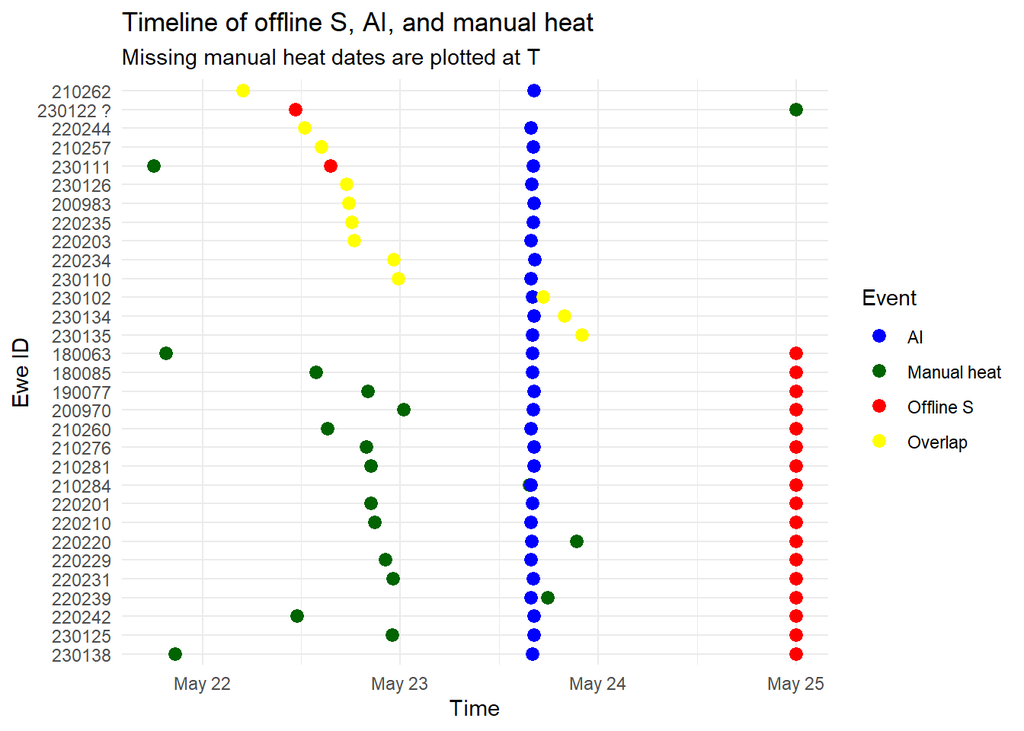

```r
plot_individual_timeline(offline_IA_Corse24)
```

### Corse 25

```r
offline_IA_Corse25 <- make_offline_IA_table(
  compare_tab = res_corse25$compare,
  prep = prep_corse25,
  IA_table = Corse2025_IA,
  time_unit = "hours"
)
```

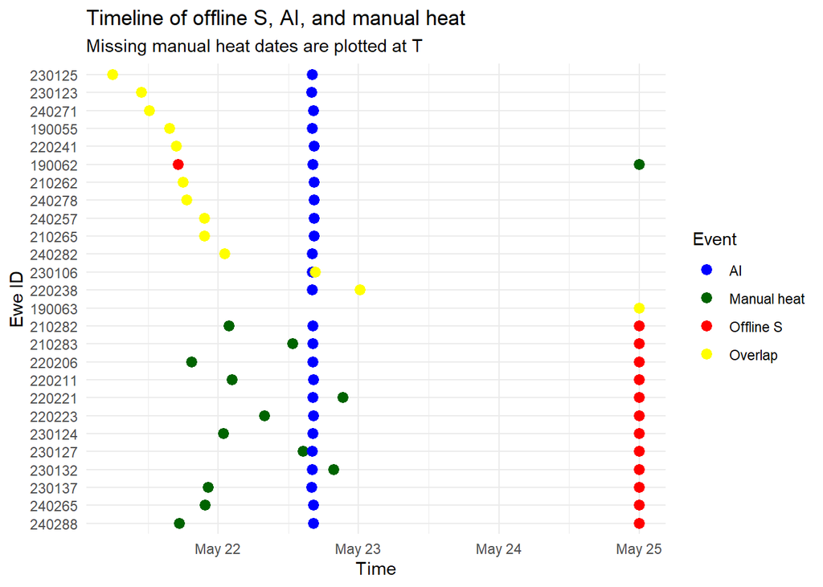

```r
plot_individual_timeline(offline_IA_Corse25)
```

### La fage 2023

```r
offline_IA_LaFage2023 <- make_offline_IA_table(
  compare_tab = res_LaFage2023$compare,
  prep = prep_LaFage2023,
  IA_table = LaFage2023_IA,
  time_unit = "hours"
)
```

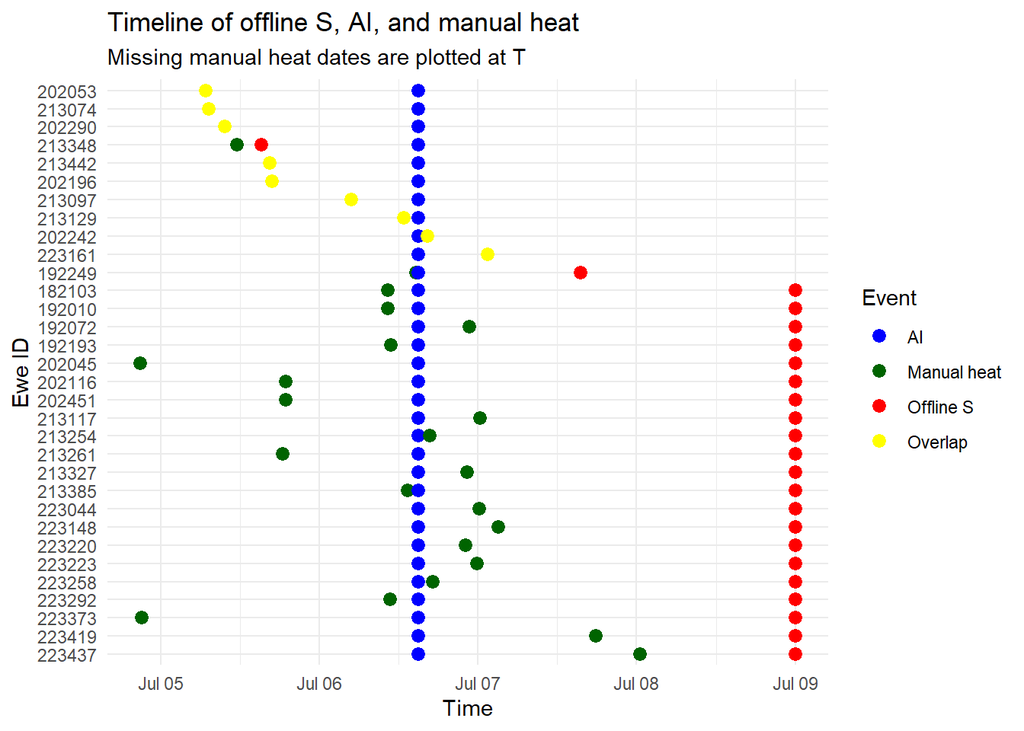

```r
plot_individual_timeline(offline_IA_LaFage2023)
```

### La fage 2025

```r
offline_IA_LaFage2025 <- make_offline_IA_table(
  compare_tab = res_LaFage2025$compare,
  prep = prep_LaFage2025,
  IA_table = LaFage2025_IA,
  time_unit = "days"
)
```

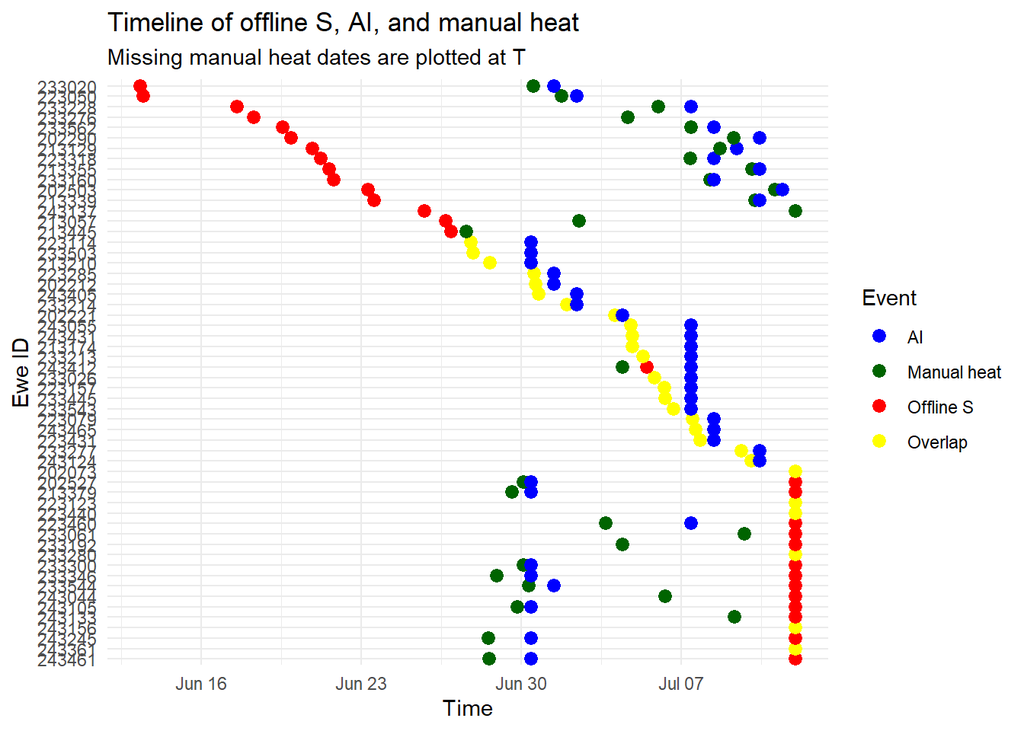

```r
plot_individual_timeline(offline_IA_LaFage2025)
```

### La Cazzote 2023

```r
offline_IA_LaCazotte2023 <- make_offline_IA_table(
  compare_tab = res_LaCazotte2023$compare,
  prep = prep_LaCazotte2023,
  IA_table = LaCazotte2023_IA,
  time_unit = "days"
)
```

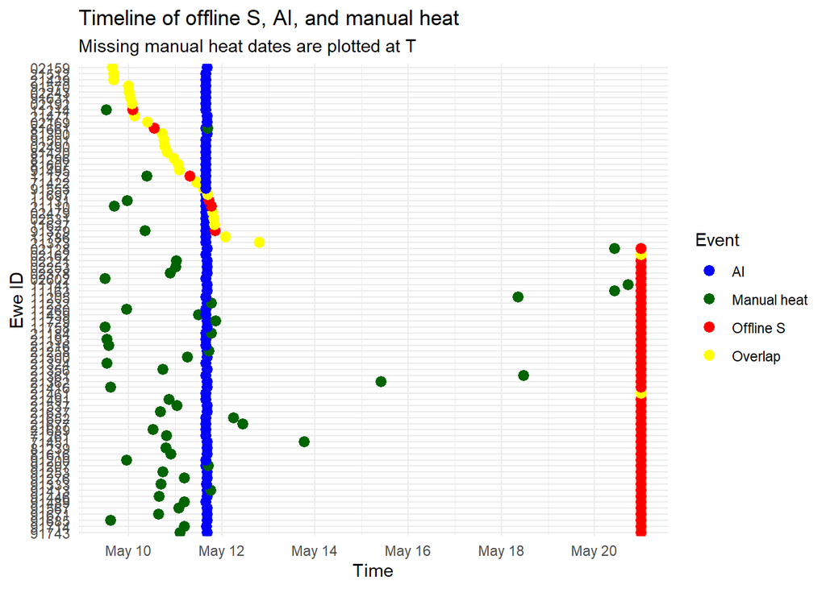

```r
plot_individual_timeline(offline_IA_LaCazotte2023)
```

### La Cazzote 2024

```r
offline_IA_LaCazotte2024 <- make_offline_IA_table(
  compare_tab = res_LaCazotte2024$compare,
  prep = prep_LaCazotte2024,
  IA_table = LaCazotte2024_IA,
  time_unit = "days"
)
```

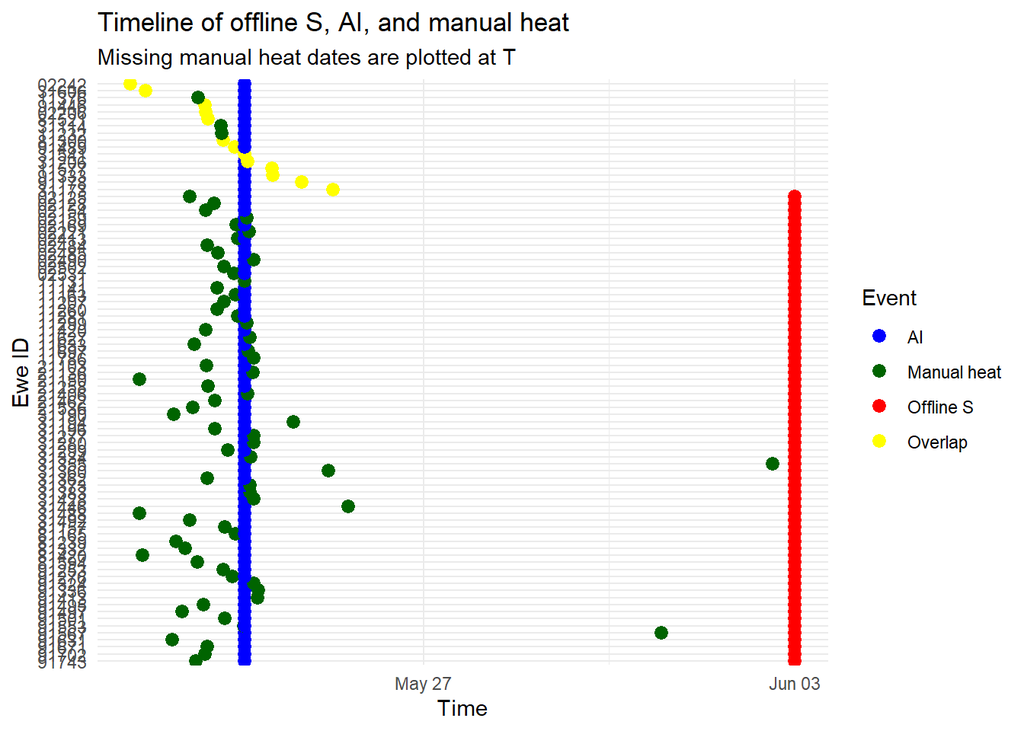

```r
plot_individual_timeline(offline_IA_LaCazotte2024)
```

## 3. Compare tables and conclusion

```r
offline_IA_tables <- list(
  Corse24 = offline_IA_Corse24,
  Corse25 = offline_IA_Corse25,
  LaCazotte2023 = offline_IA_LaCazotte2023,
  LaCazotte2024 = offline_IA_LaCazotte2024,
  LaFage2023 = offline_IA_LaFage2023,
  LaFage2025 = offline_IA_LaFage2025
)
```

```r
summary_manual_heat <- imap_dfr(offline_IA_tables, function(x, name) {

  if (!"date chaleur manuelle" %in% names(x)) {
    x$`date chaleur manuelle` <- as.POSIXct(NA, tz = "UTC")
  }

  bind_cols(
    tibble(dataset = name),
    compare_offline_with_manual_heat(x)
  )
})

DT::datatable(
  summary_manual_heat,
  options = list(scrollX = TRUE, pageLength = 10)
)
```

|  | dataset | total_ewe | n_S_detected | n_manual_detected | n_S_equal_T_manual_equal_T | mean_abs_diff_h_without_T | var_abs_diff_h_without_T |
| --- | --- | --- | --- | --- | --- | --- | --- |
| 1 | Corse24 | 31 | 14 | 30 | 0 | 1.65 | 35.52 |
| 2 | Corse25 | 26 | 13 | 24 | 1 | 0 | 0 |
| 3 | LaCazotte2023 | 78 | 30 | 76 | 2 | 6.37 | 198.9 |
| 4 | LaCazotte2024 | 83 | 16 | 83 | 0 | 0 | 0 |
| 5 | LaFage2023 | 32 | 11 | 32 | 0 | 2.59 | 55.48 |
| 6 | LaFage2025 | 56 | 37 | 49 | 6 | 145.8 | 40038.38 |

```r
summary_IA_success <- imap_dfr(offline_IA_tables, function(x, name) {

  bind_cols(
    tibble(dataset = name),
    success_by_ai_window(x) %>%
      rename(
        IA_n_0_35h = n,
        IA_n_success_0_35h = n_success,
        IA_success_percent_0_35h = percent
      )
  )
})

DT::datatable(
  summary_IA_success,
  options = list(scrollX = TRUE, pageLength = 10)
)
```

|  | dataset | IA_n_0_35h | IA_n_success_0_35h | IA_success_percent_0_35h |
| --- | --- | --- | --- | --- |
| 1 | Corse24 | 9 | 7 | 77.8 |
| 2 | Corse25 | 11 | 4 | 36.4 |
| 3 | LaCazotte2023 | 12 | 7 | 58.3 |
| 4 | LaCazotte2024 | 8 | 6 | 75 |
| 5 | LaFage2023 | 8 | 6 | 75 |
| 6 | LaFage2025 | 12 | 9 | 75 |

General comments:

When both the algorithm and manual observation detect heat, the estimated change point $S$ is generally close to the manual heat date. However, the algorithm tends to classify more cases as no rupture compared with manual observation.

The AI success rate within 0–35 hours after the estimated $S$ is relatively high, except for Corse 2025.